# ps_tutorial-3

Python Stats and Plotting Tutorial

3.1.1 Data representation and interaction

-uploaded brain_size.csv

3.1.1.2 The pandas data-frame

Reading from a CSV file:

```python
import pandas
```

```python
data = pandas.read_csv('brain_size.csv', sep=';', na_values=".")
```

```python
data
```

|  | Unnamed: 0 | Gender | FSIQ | VIQ | PIQ | Weight | Height | MRI_Count |
| --- | --- | --- | --- | --- | --- | --- | --- | --- |
| 0 | 1 | Female | 133 | 132 | 124 | 118.0 | 64.5 | 816932 |
| 1 | 2 | Male | 140 | 150 | 124 | NaN | 72.5 | 1001121 |
| 2 | 3 | Male | 139 | 123 | 150 | 143.0 | 73.3 | 1038437 |
| 3 | 4 | Male | 133 | 129 | 128 | 172.0 | 68.8 | 965353 |
| 4 | 5 | Female | 137 | 132 | 134 | 147.0 | 65.0 | 951545 |
| 5 | 6 | Female | 99 | 90 | 110 | 146.0 | 69.0 | 928799 |
| 6 | 7 | Female | 138 | 136 | 131 | 138.0 | 64.5 | 991305 |
| 7 | 8 | Female | 92 | 90 | 98 | 175.0 | 66.0 | 854258 |
| 8 | 9 | Male | 89 | 93 | 84 | 134.0 | 66.3 | 904858 |
| 9 | 10 | Male | 133 | 114 | 147 | 172.0 | 68.8 | 955466 |
| 10 | 11 | Female | 132 | 129 | 124 | 118.0 | 64.5 | 833868 |
| 11 | 12 | Male | 141 | 150 | 128 | 151.0 | 70.0 | 1079549 |
| 12 | 13 | Male | 135 | 129 | 124 | 155.0 | 69.0 | 924059 |
| 13 | 14 | Female | 140 | 120 | 147 | 155.0 | 70.5 | 856472 |
| 14 | 15 | Female | 96 | 100 | 90 | 146.0 | 66.0 | 878897 |
| 15 | 16 | Female | 83 | 71 | 96 | 135.0 | 68.0 | 865363 |
| 16 | 17 | Female | 132 | 132 | 120 | 127.0 | 68.5 | 852244 |
| 17 | 18 | Male | 100 | 96 | 102 | 178.0 | 73.5 | 945088 |
| 18 | 19 | Female | 101 | 112 | 84 | 136.0 | 66.3 | 808020 |
| 19 | 20 | Male | 80 | 77 | 86 | 180.0 | 70.0 | 889083 |
| 20 | 21 | Male | 83 | 83 | 86 | NaN | NaN | 892420 |
| 21 | 22 | Male | 97 | 107 | 84 | 186.0 | 76.5 | 905940 |
| 22 | 23 | Female | 135 | 129 | 134 | 122.0 | 62.0 | 790619 |
| 23 | 24 | Male | 139 | 145 | 128 | 132.0 | 68.0 | 955003 |
| 24 | 25 | Female | 91 | 86 | 102 | 114.0 | 63.0 | 831772 |
| 25 | 26 | Male | 141 | 145 | 131 | 171.0 | 72.0 | 935494 |
| 26 | 27 | Female | 85 | 90 | 84 | 140.0 | 68.0 | 798612 |
| 27 | 28 | Male | 103 | 96 | 110 | 187.0 | 77.0 | 1062462 |
| 28 | 29 | Female | 77 | 83 | 72 | 106.0 | 63.0 | 793549 |
| 29 | 30 | Female | 130 | 126 | 124 | 159.0 | 66.5 | 866662 |
| 30 | 31 | Female | 133 | 126 | 132 | 127.0 | 62.5 | 857782 |
| 31 | 32 | Male | 144 | 145 | 137 | 191.0 | 67.0 | 949589 |
| 32 | 33 | Male | 103 | 96 | 110 | 192.0 | 75.5 | 997925 |
| 33 | 34 | Male | 90 | 96 | 86 | 181.0 | 69.0 | 879987 |
| 34 | 35 | Female | 83 | 90 | 81 | 143.0 | 66.5 | 834344 |
| 35 | 36 | Female | 133 | 129 | 128 | 153.0 | 66.5 | 948066 |
| 36 | 37 | Male | 140 | 150 | 124 | 144.0 | 70.5 | 949395 |
| 37 | 38 | Female | 88 | 86 | 94 | 139.0 | 64.5 | 893983 |
| 38 | 39 | Male | 81 | 90 | 74 | 148.0 | 74.0 | 930016 |
| 39 | 40 | Male | 89 | 91 | 89 | 179.0 | 75.5 | 935863 |

Creating from arrays:

```python
import numpy as np
```

```python
t = np.linspace(-6, 6, 20)
```

```python
sin_t = np.sin(t)
```

```python
cos_t = np.cos(t)
```

```python
pandas.DataFrame({'t': t, 'sin': sin_t, 'cos': cos_t})
```

|  | t | sin | cos |
| --- | --- | --- | --- |
| 0 | -6.000000 | 0.279415 | 0.960170 |
| 1 | -5.368421 | 0.792419 | 0.609977 |
| 2 | -4.736842 | 0.999701 | 0.024451 |
| 3 | -4.105263 | 0.821291 | -0.570509 |
| 4 | -3.473684 | 0.326021 | -0.945363 |
| 5 | -2.842105 | -0.295030 | -0.955488 |
| 6 | -2.210526 | -0.802257 | -0.596979 |
| 7 | -1.578947 | -0.999967 | -0.008151 |
| 8 | -0.947368 | -0.811882 | 0.583822 |
| 9 | -0.315789 | -0.310567 | 0.950551 |
| 10 | 0.315789 | 0.310567 | 0.950551 |
| 11 | 0.947368 | 0.811882 | 0.583822 |
| 12 | 1.578947 | 0.999967 | -0.008151 |
| 13 | 2.210526 | 0.802257 | -0.596979 |
| 14 | 2.842105 | 0.295030 | -0.955488 |
| 15 | 3.473684 | -0.326021 | -0.945363 |
| 16 | 4.105263 | -0.821291 | -0.570509 |
| 17 | 4.736842 | -0.999701 | 0.024451 |
| 18 | 5.368421 | -0.792419 | 0.609977 |
| 19 | 6.000000 | -0.279415 | 0.960170 |

Manipulating data

```python
data.shape    # 40 rows and 8 columns
```

```
(40, 8)
```

```python
data.columns  # It has columns
```

```
Index(['Unnamed: 0', 'Gender', 'FSIQ', 'VIQ', 'PIQ', 'Weight', 'Height',
       'MRI_Count'],
      dtype='object')
```

```python
print(data['Gender'])  # Columns can be addressed by name
```

```
0     Female
1       Male
2       Male
3       Male
4     Female
5     Female
6     Female
7     Female
8       Male
9       Male
10    Female
11      Male
12      Male
13    Female
14    Female
```

[output cut: 26 more lines]

```python
data[data['Gender'] == 'Female']
```

|  | Unnamed: 0 | Gender | FSIQ | VIQ | PIQ | Weight | Height | MRI_Count |
| --- | --- | --- | --- | --- | --- | --- | --- | --- |
| 0 | 1 | Female | 133 | 132 | 124 | 118.0 | 64.5 | 816932 |
| 4 | 5 | Female | 137 | 132 | 134 | 147.0 | 65.0 | 951545 |
| 5 | 6 | Female | 99 | 90 | 110 | 146.0 | 69.0 | 928799 |
| 6 | 7 | Female | 138 | 136 | 131 | 138.0 | 64.5 | 991305 |
| 7 | 8 | Female | 92 | 90 | 98 | 175.0 | 66.0 | 854258 |
| 10 | 11 | Female | 132 | 129 | 124 | 118.0 | 64.5 | 833868 |
| 13 | 14 | Female | 140 | 120 | 147 | 155.0 | 70.5 | 856472 |
| 14 | 15 | Female | 96 | 100 | 90 | 146.0 | 66.0 | 878897 |
| 15 | 16 | Female | 83 | 71 | 96 | 135.0 | 68.0 | 865363 |
| 16 | 17 | Female | 132 | 132 | 120 | 127.0 | 68.5 | 852244 |
| 18 | 19 | Female | 101 | 112 | 84 | 136.0 | 66.3 | 808020 |
| 22 | 23 | Female | 135 | 129 | 134 | 122.0 | 62.0 | 790619 |
| 24 | 25 | Female | 91 | 86 | 102 | 114.0 | 63.0 | 831772 |
| 26 | 27 | Female | 85 | 90 | 84 | 140.0 | 68.0 | 798612 |
| 28 | 29 | Female | 77 | 83 | 72 | 106.0 | 63.0 | 793549 |
| 29 | 30 | Female | 130 | 126 | 124 | 159.0 | 66.5 | 866662 |
| 30 | 31 | Female | 133 | 126 | 132 | 127.0 | 62.5 | 857782 |
| 34 | 35 | Female | 83 | 90 | 81 | 143.0 | 66.5 | 834344 |
| 35 | 36 | Female | 133 | 129 | 128 | 153.0 | 66.5 | 948066 |
| 37 | 38 | Female | 88 | 86 | 94 | 139.0 | 64.5 | 893983 |

```python
data[data['Gender'] == 'Male']
```

|  | Unnamed: 0 | Gender | FSIQ | VIQ | PIQ | Weight | Height | MRI_Count |
| --- | --- | --- | --- | --- | --- | --- | --- | --- |
| 1 | 2 | Male | 140 | 150 | 124 | NaN | 72.5 | 1001121 |
| 2 | 3 | Male | 139 | 123 | 150 | 143.0 | 73.3 | 1038437 |
| 3 | 4 | Male | 133 | 129 | 128 | 172.0 | 68.8 | 965353 |
| 8 | 9 | Male | 89 | 93 | 84 | 134.0 | 66.3 | 904858 |
| 9 | 10 | Male | 133 | 114 | 147 | 172.0 | 68.8 | 955466 |
| 11 | 12 | Male | 141 | 150 | 128 | 151.0 | 70.0 | 1079549 |
| 12 | 13 | Male | 135 | 129 | 124 | 155.0 | 69.0 | 924059 |
| 17 | 18 | Male | 100 | 96 | 102 | 178.0 | 73.5 | 945088 |
| 19 | 20 | Male | 80 | 77 | 86 | 180.0 | 70.0 | 889083 |
| 20 | 21 | Male | 83 | 83 | 86 | NaN | NaN | 892420 |
| 21 | 22 | Male | 97 | 107 | 84 | 186.0 | 76.5 | 905940 |
| 23 | 24 | Male | 139 | 145 | 128 | 132.0 | 68.0 | 955003 |
| 25 | 26 | Male | 141 | 145 | 131 | 171.0 | 72.0 | 935494 |
| 27 | 28 | Male | 103 | 96 | 110 | 187.0 | 77.0 | 1062462 |
| 31 | 32 | Male | 144 | 145 | 137 | 191.0 | 67.0 | 949589 |
| 32 | 33 | Male | 103 | 96 | 110 | 192.0 | 75.5 | 997925 |
| 33 | 34 | Male | 90 | 96 | 86 | 181.0 | 69.0 | 879987 |
| 36 | 37 | Male | 140 | 150 | 124 | 144.0 | 70.5 | 949395 |
| 38 | 39 | Male | 81 | 90 | 74 | 148.0 | 74.0 | 930016 |
| 39 | 40 | Male | 89 | 91 | 89 | 179.0 | 75.5 | 935863 |

```python
data[data['Gender'] == 'Female']['VIQ']
```

```
0     132
4     132
5      90
6     136
7      90
10    129
13    120
14    100
15     71
16    132
18    112
22    129
24     86
26     90
28     83
29    126
30    126
34     90
35    129
37     86
Name: VIQ, dtype: int64
```

```python
data[data['Gender'] == 'Male']['VIQ']
```

```
1     150
2     123
3     129
8      93
9     114
11    150
12    129
17     96
19     77
20     83
21    107
23    145
25    145
27     96
31    145
32     96
33     96
36    150
38     90
39     91
Name: VIQ, dtype: int64
```

```python
data[data['Gender'] == 'Female']['VIQ'].mean()
```

```
109.45
```

```python
data[data['Gender'] == 'Male']['VIQ'].mean()
```

```
115.25
```

groupby:

```python
groupby_gender = data.groupby('Gender')
```

```python
for gender, value in groupby_gender['VIQ']:
    print((gender, value.mean()))
```

```
('Female', 109.45)
('Male', 115.25)
```

Exercise

What is the mean value for VIQ for the full population?

```python
data['VIQ'].mean ()
```

```
112.35
```

How many males/females were included in this study?

```python
data['Gender']
```

```
0     Female
1       Male
2       Male
3       Male
4     Female
5     Female
6     Female
7     Female
8       Male
9       Male
10    Female
11      Male
12      Male
13    Female
14    Female
```

[output cut: 26 more lines]

```python
groupby_gender = data.groupby('Gender')
```

```
Female         AxesSubplot(0.1,0.15;0.363636x0.75)
Male      AxesSubplot(0.536364,0.15;0.363636x0.75)
dtype: object
```

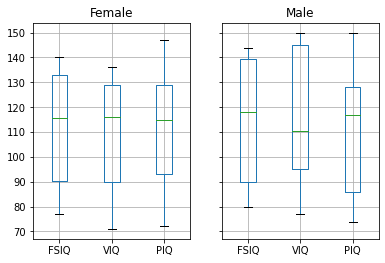

```python
groupby_gender.boxplot(column=['FSIQ', 'VIQ', 'PIQ'])
```

Plotting Data

```python
from pandas import plotting
```

```
array([[<AxesSubplot:xlabel='Weight', ylabel='Weight'>,
        <AxesSubplot:xlabel='Height', ylabel='Weight'>,
        <AxesSubplot:xlabel='MRI_Count', ylabel='Weight'>],
       [<AxesSubplot:xlabel='Weight', ylabel='Height'>,
        <AxesSubplot:xlabel='Height', ylabel='Height'>,
        <AxesSubplot:xlabel='MRI_Count', ylabel='Height'>],
       [<AxesSubplot:xlabel='Weight', ylabel='MRI_Count'>,
        <AxesSubplot:xlabel='Height', ylabel='MRI_Count'>,
        <AxesSubplot:xlabel='MRI_Count', ylabel='MRI_Count'>]],
      dtype=object)
```

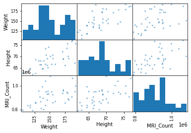

```python
plotting.scatter_matrix(data[['Weight', 'Height', 'MRI_Count']])
```

```
array([[<AxesSubplot:xlabel='PIQ', ylabel='PIQ'>,
        <AxesSubplot:xlabel='VIQ', ylabel='PIQ'>,
        <AxesSubplot:xlabel='FSIQ', ylabel='PIQ'>],
       [<AxesSubplot:xlabel='PIQ', ylabel='VIQ'>,
        <AxesSubplot:xlabel='VIQ', ylabel='VIQ'>,
        <AxesSubplot:xlabel='FSIQ', ylabel='VIQ'>],
       [<AxesSubplot:xlabel='PIQ', ylabel='FSIQ'>,
        <AxesSubplot:xlabel='VIQ', ylabel='FSIQ'>,
        <AxesSubplot:xlabel='FSIQ', ylabel='FSIQ'>]], dtype=object)
```

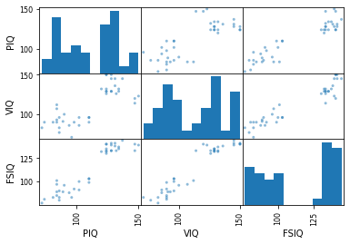

```python
plotting.scatter_matrix(data[['PIQ', 'VIQ', 'FSIQ']])
```

Exercise

Plot the scatter matrix for males only, and for females only. Do you think that the 2 sub-populations correspond to gender?

```
array([[<AxesSubplot:xlabel='PIQ', ylabel='PIQ'>,
        <AxesSubplot:xlabel='VIQ', ylabel='PIQ'>,
        <AxesSubplot:xlabel='FSIQ', ylabel='PIQ'>],
       [<AxesSubplot:xlabel='PIQ', ylabel='VIQ'>,
        <AxesSubplot:xlabel='VIQ', ylabel='VIQ'>,
        <AxesSubplot:xlabel='FSIQ', ylabel='VIQ'>],
       [<AxesSubplot:xlabel='PIQ', ylabel='FSIQ'>,
        <AxesSubplot:xlabel='VIQ', ylabel='FSIQ'>,
        <AxesSubplot:xlabel='FSIQ', ylabel='FSIQ'>]], dtype=object)
```

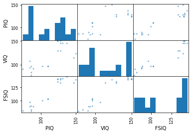

```python
plotting.scatter_matrix(data[data['Gender'] == 'Male'][['PIQ', 'VIQ', 'FSIQ']])
```

```
array([[<AxesSubplot:xlabel='PIQ', ylabel='PIQ'>,
        <AxesSubplot:xlabel='VIQ', ylabel='PIQ'>,
        <AxesSubplot:xlabel='FSIQ', ylabel='PIQ'>],
       [<AxesSubplot:xlabel='PIQ', ylabel='VIQ'>,
        <AxesSubplot:xlabel='VIQ', ylabel='VIQ'>,
        <AxesSubplot:xlabel='FSIQ', ylabel='VIQ'>],
       [<AxesSubplot:xlabel='PIQ', ylabel='FSIQ'>,
        <AxesSubplot:xlabel='VIQ', ylabel='FSIQ'>,
        <AxesSubplot:xlabel='FSIQ', ylabel='FSIQ'>]], dtype=object)
```

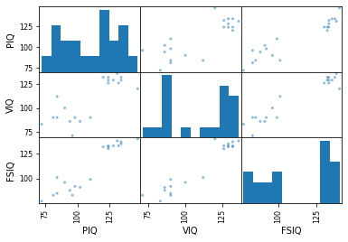

```python
plotting.scatter_matrix(data[data['Gender'] == 'Female'][['PIQ', 'VIQ', 'FSIQ']])
```

3.1.2 Hypothesis testing: comparing two groups

```python
from scipy import stats
```

3.1.2.1. Student’s t-test: the simplest statistical test

```python
stats.ttest_1samp(data['VIQ'], 0)
```

```
Ttest_1sampResult(statistic=30.088099970849328, pvalue=1.3289196468728067e-28)
```

```python
female_viq = data[data['Gender'] == 'Female']['VIQ']
```

```python
male_viq = data[data['Gender'] == 'Male']['VIQ']
```

```python
stats.ttest_ind(female_viq, male_viq)
```

```
Ttest_indResult(statistic=-0.7726161723275011, pvalue=0.44452876778583217)
```

3.1.2.2 Paired tests: repeated measurements on the same individuals

```python
stats.ttest_ind(data['FSIQ'], data['PIQ'])
```

```
Ttest_indResult(statistic=0.465637596380964, pvalue=0.6427725009414841)
```

```python
stats.ttest_rel(data['FSIQ'], data['PIQ'])
```

```
Ttest_relResult(statistic=1.7842019405859857, pvalue=0.08217263818364236)
```

```python
stats.ttest_1samp(data['FSIQ'] - data['PIQ'], 0)
```

```
Ttest_1sampResult(statistic=1.7842019405859857, pvalue=0.08217263818364236)
```

```python
stats.wilcoxon(data['FSIQ'], data['PIQ'])
```

```
WilcoxonResult(statistic=274.5, pvalue=0.10659492713506856)
```

Exercise

Test the difference between weights in males and females.

```python
from scipy import stats
```

```python
import pandas
```

```python
data = pandas.read_csv('brain_size.csv', sep=';', na_values=".")
```

```python
stats.ttest_ind(data[data['Gender'] == 'Female']['Weight'], data[data['Gender'] == 'Male']['Weight'])
```

```
Ttest_indResult(statistic=nan, pvalue=nan)
```

```python
stats.ttest_1samp(data[data['Gender'] == 'Female']['VIQ'] - data[data['Gender'] == 'Male']['VIQ'], 0)
```

```
Ttest_1sampResult(statistic=nan, pvalue=nan)
```

Conclusion: we find that the data does not support the hypothesis that males and females have different VIQ.

3.1.3. Linear models, multiple factors, and analysis of variance

```python
import numpy as np
```

```python
x = np.linspace(-5, 5, 20)
```

```python
np.random.seed(1)
```

```python
y = -5 + 3*x + 4 * np.random.normal(size=x.shape)
```

```python
data = pandas.DataFrame({'x': x, 'y': y})
```

```python
from statsmodels.formula.api import ols
```

```python
model = ols("y ~ x", data).fit()
```

```python
print(model.summary())
```

```
                            OLS Regression Results
==============================================================================
Dep. Variable:                      y   R-squared:                       0.804
Model:                            OLS   Adj. R-squared:                  0.794
Method:                 Least Squares   F-statistic:                     74.03
Date:                Fri, 08 Jul 2022   Prob (F-statistic):           8.56e-08
Time:                        13:01:45   Log-Likelihood:                -57.988
No. Observations:                  20   AIC:                             120.0
Df Residuals:                      18   BIC:                             122.0
Df Model:                           1
Covariance Type:            nonrobust
==============================================================================
                 coef    std err          t      P>|t|      [0.025      0.975]
------------------------------------------------------------------------------
Intercept     -5.5335      1.036     -5.342      0.000      -7.710      -3.357
x              2.9369      0.341      8.604      0.000       2.220       3.654
==============================================================================
Omnibus:                        0.100   Durbin-Watson:                   2.956
Prob(Omnibus):                  0.951   Jarque-Bera (JB):                0.322
Skew:                          -0.058   Prob(JB):                        0.851
Kurtosis:                       2.390   Cond. No.                         3.03
==============================================================================

Notes:
[1] Standard Errors assume that the covariance matrix of the errors is correctly specified.
```

```python
data = pandas.read_csv('brain_size.csv', sep=';', na_values=".")
```

```python
model = ols("VIQ ~ Gender + 1", data).fit()
```

```python
print(model.summary())
```

```
                            OLS Regression Results
==============================================================================
Dep. Variable:                    VIQ   R-squared:                       0.015
Model:                            OLS   Adj. R-squared:                 -0.010
Method:                 Least Squares   F-statistic:                    0.5969
Date:                Fri, 08 Jul 2022   Prob (F-statistic):              0.445
Time:                        13:02:09   Log-Likelihood:                -182.42
No. Observations:                  40   AIC:                             368.8
Df Residuals:                      38   BIC:                             372.2
Df Model:                           1
Covariance Type:            nonrobust
==================================================================================
                     coef    std err          t      P>|t|      [0.025      0.975]
----------------------------------------------------------------------------------
Intercept        109.4500      5.308     20.619      0.000      98.704     120.196
Gender[T.Male]     5.8000      7.507      0.773      0.445      -9.397      20.997
==============================================================================
Omnibus:                       26.188   Durbin-Watson:                   1.709
Prob(Omnibus):                  0.000   Jarque-Bera (JB):                3.703
Skew:                           0.010   Prob(JB):                        0.157
Kurtosis:                       1.510   Cond. No.                         2.62
==============================================================================

Notes:
[1] Standard Errors assume that the covariance matrix of the errors is correctly specified.
```

```python
data_fisq = pandas.DataFrame({'iq': data['FSIQ'], 'type': 'fsiq'})
```

```python
data_piq = pandas.DataFrame({'iq': data['PIQ'], 'type': 'piq'})
```

```python
data_long = pandas.concat((data_fisq, data_piq))
```

```python
print(data_long)
```

```
     iq  type
0   133  fsiq
1   140  fsiq
2   139  fsiq
3   133  fsiq
4   137  fsiq
..  ...   ...
35  128   piq
36  124   piq
37   94   piq
38   74   piq
39   89   piq

[80 rows x 2 columns]
```

```python
model = ols("iq ~ type", data_long).fit()
```

```python
print(model.summary())
```

```
                            OLS Regression Results
==============================================================================
Dep. Variable:                     iq   R-squared:                       0.003
Model:                            OLS   Adj. R-squared:                 -0.010
Method:                 Least Squares   F-statistic:                    0.2168
Date:                Fri, 08 Jul 2022   Prob (F-statistic):              0.643
Time:                        13:03:01   Log-Likelihood:                -364.35
No. Observations:                  80   AIC:                             732.7
Df Residuals:                      78   BIC:                             737.5
Df Model:                           1
Covariance Type:            nonrobust
===============================================================================
                  coef    std err          t      P>|t|      [0.025      0.975]
-------------------------------------------------------------------------------
Intercept     113.4500      3.683     30.807      0.000     106.119     120.781
type[T.piq]    -2.4250      5.208     -0.466      0.643     -12.793       7.943
==============================================================================
Omnibus:                      164.598   Durbin-Watson:                   1.531
Prob(Omnibus):                  0.000   Jarque-Bera (JB):                8.062
Skew:                          -0.110   Prob(JB):                       0.0178
Kurtosis:                       1.461   Cond. No.                         2.62
==============================================================================

Notes:
[1] Standard Errors assume that the covariance matrix of the errors is correctly specified.
```

```python
stats.ttest_ind(data['FSIQ'], data['PIQ'])
```

```
Ttest_indResult(statistic=0.465637596380964, pvalue=0.6427725009414841)
```

3.1.3.2. Multiple Regression: including multiple factors

```python
data = pandas.read_csv('iris.csv')
```

```python
model = ols('sepal_width ~ name + petal_length', data).fit()
```

```python
print(model.summary())
```

```
                            OLS Regression Results
==============================================================================
Dep. Variable:            sepal_width   R-squared:                       0.478
Model:                            OLS   Adj. R-squared:                  0.468
Method:                 Least Squares   F-statistic:                     44.63
Date:                Fri, 08 Jul 2022   Prob (F-statistic):           1.58e-20
Time:                        13:04:16   Log-Likelihood:                -38.185
No. Observations:                 150   AIC:                             84.37
Df Residuals:                     146   BIC:                             96.41
Df Model:                           3
Covariance Type:            nonrobust
======================================================================================
                         coef    std err          t      P>|t|      [0.025      0.975]
--------------------------------------------------------------------------------------
Intercept              2.9813      0.099     29.989      0.000       2.785       3.178
name[T.versicolor]    -1.4821      0.181     -8.190      0.000      -1.840      -1.124
name[T.virginica]     -1.6635      0.256     -6.502      0.000      -2.169      -1.158
petal_length           0.2983      0.061      4.920      0.000       0.178       0.418
==============================================================================
Omnibus:                        2.868   Durbin-Watson:                   1.753
Prob(Omnibus):                  0.238   Jarque-Bera (JB):                2.885
Skew:                          -0.082   Prob(JB):                        0.236
Kurtosis:                       3.659   Cond. No.                         54.0
==============================================================================

Notes:
[1] Standard Errors assume that the covariance matrix of the errors is correctly specified.
```

```python
print(model.f_test([0, 1, -1, 0]))
```

```
<F test: F=3.245335346574177, p=0.07369058781701142, df_denom=146, df_num=1>
```

Exercise

```python
data = pandas.read_csv('brain_size.csv')
```

```python
print(model.f_test([0, 1, -1, 0]))
```

```
<F test: F=3.245335346574177, p=0.07369058781701142, df_denom=146, df_num=1>
```

3.1.4. More visualization: seaborn for statistical exploration

```python
import urllib
```

```python
import os
```

```python
import matplotlib.pyplot as plt
```

```python
import pandas
```

```python
if not os.path.exists('CPS_85_Wages.txt'):
    # Download the file if it is not present
    urllib.urlretrieve('http://lib.stat.cmu.edu/datasets/CPS_85_Wages',
                       'CPS_85_Wages.txt')
```

```python
names = [
    'EDUCATION: Number of years of education',
    'SOUTH: 1=Person lives in South, 0=Person lives elsewhere',
    'SEX: 1=Female, 0=Male',
    'EXPERIENCE: Number of years of work experience',
    'UNION: 1=Union member, 0=Not union member',
    'WAGE: Wage (dollars per hour)',
    'AGE: years',
    'RACE: 1=Other, 2=Hispanic, 3=White',
    'OCCUPATION: 1=Management, 2=Sales, 3=Clerical, 4=Service, 5=Professional, 6=Other',
    'SECTOR: 0=Other, 1=Manufacturing, 2=Construction',
    'MARR: 0=Unmarried,  1=Married',
]
```

```python
short_names = [n.split(':')[0] for n in names]
```

```python
import seaborn
```

```python
import numpy as np
```

```python
import seaborn
```

-having difficult time with seaborn section